# About

The goal of this project is to create a classifier model that can determine if a product review expresses positive or negative sentiment about a product. The data for this project is from amazon product reviews.

# Setup

We begin by performing the necessary imports.

```python
import math
import string

import matplotlib.pyplot as plt
import numpy as np
import pandas as pd
import seaborn as sns

from sklearn.linear_model import LogisticRegression
from sklearn.metrics import accuracy_score
from sklearn.model_selection import train_test_split
from sklearn.feature_extraction.text import CountVectorizer
from sklearn.feature_extraction import DictVectorizer

sns.set()
%matplotlib inline
```

Read in data and examine.

```python
from google.colab import drive
drive.mount('/content/drive')
```

```python
products = pd.read_csv('/content/drive/MyDrive/Data Science Projects/data/food_products.csv')
np.random.seed(416)
products.head()
```

|  | product_id | summary | review | rating |
| --- | --- | --- | --- | --- |
| 0 | 4408 | Does increase milk supply | This really helped to increase my milk supply.... | 3.0 |
| 1 | 4209 | One bad packet ruins the product! | I should have stayed with Idahoan brand. Poor ... | 1.0 |
| 2 | 8623 | CAULIFLOWER PASTA!? | As the pasta cooked, I read the box to see wha... | 4.0 |
| 3 | 9439 | Tasty and inexpensive | I really like this cereal. The flavor is sligh... | 5.0 |
| 4 | 7110 | I'm Confused | The label on the bowl says 35 grams is in the ... | 2.0 |

Ignore reviews with neutral sentiment.

```python
products = products[products['rating'] != 3].copy()

len(products)
```

```
889
```

Confirm removal with chart.

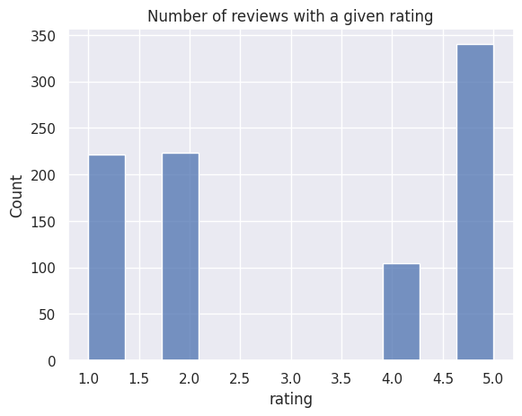

```python
plt.title('Number of reviews with a given rating')
sns.histplot(products['rating'])
```

Set ratings with 4 or more to be positive, and 2 or less to be negative.

```python
products['sentiment'] = products['rating'].apply(
    lambda rating : +1 if rating > 3 else -1
    )
products.head()
```

|  | product_id | summary | review | rating | sentiment |
| --- | --- | --- | --- | --- | --- |
| 1 | 4209 | One bad packet ruins the product! | I should have stayed with Idahoan brand. Poor ... | 1.0 | -1 |
| 2 | 8623 | CAULIFLOWER PASTA!? | As the pasta cooked, I read the box to see wha... | 4.0 | 1 |
| 3 | 9439 | Tasty and inexpensive | I really like this cereal. The flavor is sligh... | 5.0 | 1 |
| 4 | 7110 | I'm Confused | The label on the bowl says 35 grams is in the ... | 2.0 | -1 |
| 5 | 1373 | Flat | Doesn't taste like ginger. Thought it would s... | 2.0 | -1 |

```python
example_product = products.iloc[21]
print(f"Rating : {example_product['rating']} (Sentiment={example_product['sentiment']})")
print("Summary:", example_product["summary"])
print("Review :", example_product["review"])
```

```
Rating : 4.0 (Sentiment=1)
Summary: It's PRIME-arily Lobster
Review : if it's primarily made from lobster, what else is in there? I wonder. Primarily...Who uses a word like that on a food label? It's primarily delicious among other things, things we usually have no energy to talk about after eating a fine meal. I'm so full of primarily lobster bisque that I'v…
```

Helper function to remove punctuation.

```python
def remove_punctuation(text):
    """
    Remove any punctuation in text.
    """
    if type(text) is str:
        return text.translate(str.maketrans('', '', string.punctuation))
    else:
        return ''

products['review_clean'] = products['review'].apply(remove_punctuation)
```

Use vectorizer to get word counts.

```python
vectorizer = CountVectorizer()
count_matrix = vectorizer.fit_transform(products['review_clean'])

features = vectorizer.get_feature_names_out()

product_data = pd.DataFrame(count_matrix.toarray(),
        index=products.index,
        columns=features)

product_data['sentiment'] = products['sentiment']
product_data['review_clean'] = products['review_clean']
product_data['summary'] = products['summary']

product_data.head()
```

|  | 0000 | 002 | 004 | 004oz | 012months | 032 | 051 | 08 | 0f | 10 | ... | zico1 | zico3 | zicos | zillion | zinger | zip | ziplock | sentiment | review_clean | summary |
| --- | --- | --- | --- | --- | --- | --- | --- | --- | --- | --- | --- | --- | --- | --- | --- | --- | --- | --- | --- | --- | --- |
| 1 | 0 | 0 | 0 | 0 | 0 | 0 | 0 | 0 | 0 | 0 | ... | 0 | 0 | 0 | 0 | 0 | 0 | 0 | -1 | I should have stayed with Idahoan brand Poor B... | One bad packet ruins the product! |
| 2 | 0 | 0 | 0 | 0 | 0 | 0 | 0 | 0 | 0 | 0 | ... | 0 | 0 | 0 | 0 | 0 | 0 | 0 | 1 | As the pasta cooked I read the box to see what... | CAULIFLOWER PASTA!? |
| 3 | 0 | 0 | 0 | 0 | 0 | 0 | 0 | 0 | 0 | 0 | ... | 0 | 0 | 0 | 0 | 0 | 0 | 0 | 1 | I really like this cereal The flavor is slight... | Tasty and inexpensive |
| 4 | 0 | 0 | 0 | 0 | 0 | 0 | 0 | 0 | 0 | 0 | ... | 0 | 0 | 0 | 0 | 0 | 0 | 0 | -1 | The label on the bowl says 35 grams is in the ... | I'm Confused |
| 5 | 0 | 0 | 0 | 0 | 0 | 0 | 0 | 0 | 0 | 0 | ... | 0 | 0 | 0 | 0 | 0 | 0 | 0 | -1 | Doesnt taste like ginger Thought it would sav... | Flat |

5 rows × 7628 columns

Perform train/test split.

```python
train_data, test_and_validation_data = train_test_split(
    product_data,
    test_size=0.2,
    random_state=3
    )

validation_data, test_data = train_test_split(
    test_and_validation_data,
    test_size=0.5,
    random_state=3
    )
```

# Majority Class Classifier

Create majority class classifier as a baseline.

```python
majority_label = train_data['sentiment'].value_counts().idxmax()
majority_classifier_validation_accuracy = (
    validation_data['sentiment'] == majority_label
    ).sum() / len(validation_data['sentiment'])
```

# Sentiment Classifier

Create sentiment classifier.

```python
sentiment_model = LogisticRegression(penalty='l2', C=1e23, random_state=1)
sentiment_model.fit(train_data[features], train_data['sentiment'])
```

```
LogisticRegression(C=1e+23, random_state=1)
```

Examine smallest and largest coefficients.

```python
coefficients = sentiment_model.coef_

print('Smallest coefficient', coefficients.min())
print('Largest coefficient:', coefficients.max())
```

```
Smallest coefficient -5.9876466234317895
Largest coefficient: 11.015982338842841
```

Examine most positive and negative words

```python
most_negative_word = train_data.columns[np.argmin(coefficients)]
most_positive_word = train_data.columns[np.argmax(coefficients)]
```

```python
print('Most negative word:', most_negative_word)
print('Most positive word:', most_positive_word)
```

```
Most negative word: not
Most positive word: great
```

Make some initial predictions on a small sample of the validation data.

```python
sample_data = validation_data[8:11]
sample_data[['sentiment', 'review_clean', 'summary']]
```

|  | sentiment | review_clean | summary |
| --- | --- | --- | --- |
| 493 | -1 | The Chocolate Espresso flavor of the thinkThin... | Not a good taste |
| 311 | 1 | hard candy with a smooth creamy milk taste i l... | great taste |
| 570 | 1 | When I was growing up split pea soup was a uni... | More like split pea stew |

```python
print('  Prob Negative, Prob Positive')
print(sentiment_model.predict_proba(sample_data[features]))
```

```
  Prob Negative, Prob Positive
[[1.00000000e+00 4.94811120e-17]
 [1.81738360e-07 9.99999818e-01]
 [1.00000000e+00 1.07223685e-11]]
```

```python
print('Predicted labels')
print(sentiment_model.predict(sample_data[features]))
```

```
Predicted labels
[-1  1 -1]
```

Now, predict the most positive and negative review using the entire validation set.

```python
most_positive_review = validation_data.iloc[sentiment_model.predict_proba(
    validation_data[features])[:, 1].argmax()]['review_clean']
most_negative_review = validation_data.iloc[sentiment_model.predict_proba(
    validation_data[features])[:, 0].argmax()]['review_clean']
```

```python
print('Most Positive Review:')
print(most_positive_review)
print()
print('Most Negative Review:')
print(most_negative_review)
```

```
Most Positive Review:
I have been on an organic foods diet for almost a year now and I have become much more sensitive to what I eat and drink Out are the energy drinks loaded with sugars caffeine and artificial ingredients In are the more gentler and natural energy boosters This was  a surprise for me I really liked it …

Most Negative Review:
The Chocolate Espresso flavor of the thinkThin bars is the only one I have tasted and I found it disappointing  There was no coffee flavor to the bar other than bitterness  Is that supposed to be the espresso flavor  I have tasted many other things with a better coffee flavor  The chocolate flavor i…
```

Calculate accuracy of our predictions.

```python
sentiment_model_validation_accuracy = accuracy_score(
    validation_data['sentiment'],
    sentiment_model.predict(
        validation_data[features]
        )
    )
```

# Confusion Matrix

Helper function for plotting the confusion matrix.

```python
def plot_confusion_matrix(tp, fp, fn, tn):
    """
    Plots a confusion matrix using the values
       tp - True Positive
       fp - False Positive
       fn - False Negative
       tn - True Negative
    """
    data = np.matrix([[tp, fp], [fn, tn]])

    sns.heatmap(data,annot=True,xticklabels=['Actual Pos', 'Actual Neg']
              ,yticklabels=['Pred. Pos', 'Pred. Neg'])
```

Create confusion matrix from validation set predictions.

```python
from sklearn.metrics import confusion_matrix

tn, fp, fn, tp = confusion_matrix(
    validation_data['sentiment'],
    sentiment_model.predict(
        validation_data[features]
        )
    ).ravel()
```

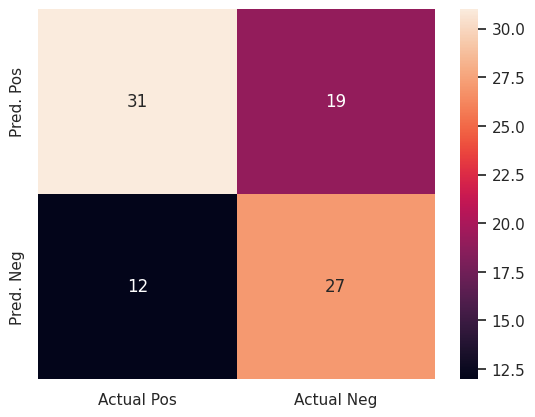

```python
plot_confusion_matrix(tp=tp, fp=fp, tn=tn, fn=fn)
```

# Logistic Regression

Now we will perfom logistic regression with l2 regularization in order to minimize our chances of overfitting, training with various magnitudes of lambda. We will record the coefficients for each word and their respective coefficient values with each different l2 penalty, as well as the training and validation accuracy for each different model.

```python
l2_penalties = [0.01, 1, 4, 10, 1e2, 1e3, 1e5]
l2_penalty_names = [f'coefficients [L2={l2_penalty:.0e}]'
                    for l2_penalty in l2_penalties]

coef_table = pd.DataFrame(columns=['word'] + l2_penalty_names)
coef_table['word'] = features

accuracy_data = []

for l2_penalty, l2_penalty_column_name in zip(l2_penalties, l2_penalty_names):
    model = LogisticRegression(
        penalty='l2',
        C=(1 / l2_penalty),
        fit_intercept=False,
        random_state=1
        )
    model.fit(
        train_data[features],
        train_data['sentiment']
        )
    coef_table[l2_penalty_column_name] = model.coef_[0]
    accuracy_data.append(
        {
            'l2_penalty': l2_penalty,
            'train_accuracy': accuracy_score(
                train_data['sentiment'],
                model.predict(
                    train_data[features]
                    )
                ),
            'validation_accuracy': accuracy_score(
                validation_data['sentiment'],
                model.predict(
                    validation_data[features]
                    )
                )
            }
        )


accuracies_table = pd.DataFrame(accuracy_data)
```

```python
coef_table
```

|  | word | coefficients [L2=1e-02] | coefficients [L2=1e+00] | coefficients [L2=4e+00] | coefficients [L2=1e+01] | coefficients [L2=1e+02] | coefficients [L2=1e+03] | coefficients [L2=1e+05] |
| --- | --- | --- | --- | --- | --- | --- | --- | --- |
| 0 | 0000 | 0.107215 | 0.030762 | 0.017188 | 0.010918 | 0.002989 | 0.000476 | 5.045637e-06 |
| 1 | 002 | -0.019075 | -0.001973 | -0.002153 | -0.001966 | -0.000746 | -0.000099 | -4.085575e-06 |
| 2 | 004 | -0.019075 | -0.001973 | -0.002153 | -0.001966 | -0.000746 | -0.000099 | -4.085575e-06 |
| 3 | 004oz | -0.019075 | -0.001973 | -0.002153 | -0.001966 | -0.000746 | -0.000099 | -4.085575e-06 |
| 4 | 012months | 0.032081 | 0.001532 | 0.001615 | 0.001501 | 0.001130 | 0.000399 | 5.049857e-06 |
| ... | ... | ... | ... | ... | ... | ... | ... | ... |
| 7620 | zicos | -0.131704 | -0.055637 | -0.030848 | -0.018653 | -0.003718 | -0.000447 | -4.923324e-06 |
| 7621 | zillion | -0.073327 | -0.037442 | -0.029708 | -0.020870 | -0.004020 | -0.000466 | -4.973674e-06 |
| 7622 | zinger | -0.029916 | -0.003715 | -0.004730 | -0.004572 | -0.002496 | -0.000412 | -4.893557e-06 |
| 7623 | zip | 0.111437 | 0.051768 | 0.033141 | 0.022192 | 0.005980 | 0.001038 | 1.027987e-05 |
| 7624 | ziplock | 0.085013 | 0.035280 | 0.020182 | 0.012145 | 0.002320 | 0.000227 | 2.699920e-07 |

7625 rows × 8 columns

```python
accuracies_table
```

|  | l2_penalty | train_accuracy | validation_accuracy |
| --- | --- | --- | --- |
| 0 | 0.01 | 1.000000 | 0.651685 |
| 1 | 1.00 | 0.998594 | 0.685393 |
| 2 | 4.00 | 0.995781 | 0.685393 |
| 3 | 10.00 | 0.976090 | 0.696629 |
| 4 | 100.00 | 0.895921 | 0.719101 |
| 5 | 1000.00 | 0.734177 | 0.674157 |
| 6 | 100000.00 | 0.502110 | 0.516854 |

Now, identify positive and negative words.

```python
positive_words = coef_table.loc[coef_table['coefficients [L2=1e+00]'].nlargest(5).index, 'word']
negative_words = coef_table.loc[coef_table['coefficients [L2=1e+00]'].nsmallest(5).index, 'word']
```

```python
print(positive_words)
print(negative_words)
```

```
3096      great
863        best
4981    perfect
3037       good
1925       days
Name: word, dtype: object
4586          not
1398    chocolate
6862      thought
919         bland
4177          may
Name: word, dtype: object
```

Plot most positive and negative words.

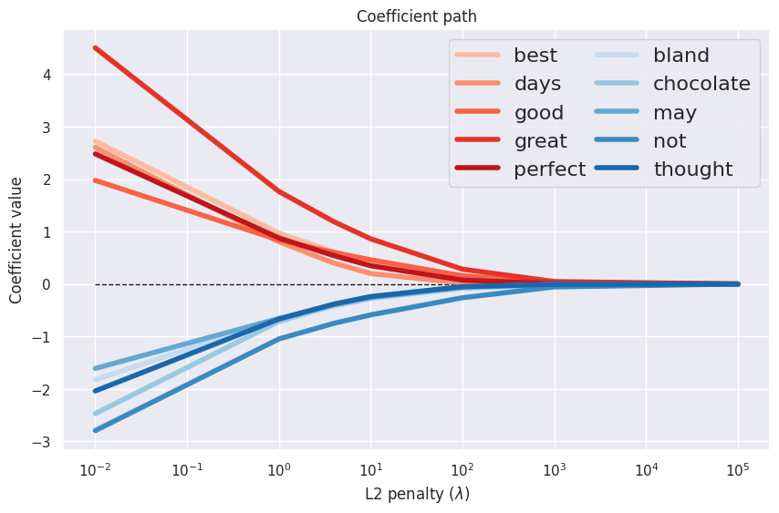

```python
def make_coefficient_plot(table, positive_words, negative_words, l2_penalty_list):
    """
    Makes a plot of coefficients, given a table where rows correspond to words and
    columns correspond to the l2 penalty, a list of positive words, a list of
    negative words, and a list of l2 penalties.
    """
    def get_cmap_value(cmap, i, total_words):
        """
        Computes a nice scaling of from i=0 to i=total_words - 1
        for the given cmap
        """
        return cmap(0.8 * ((i + 1) / (total_words * 1.2) + 0.15))


    def plot_coeffs_for_words(ax, words, cmap):
        """
        Given an axes to plot on and a list of words and a cmap,
        plots the coefficient paths for each word in words
        """
        words_df = table[table['word'].isin(words)]
        words_df = words_df.reset_index(drop=True)

        for i, row in words_df.iterrows():
            color = get_cmap_value(cmap, i, len(words))
            ax.plot(xx, row[row.index != 'word'], '-',
                    label=row['word'], linewidth=4.0, color=color)

    fig, ax = plt.subplots(1, figsize=(10, 6))

    xx = l2_penalty_list
    ax.plot(xx, [0.] * len(xx), '--', linewidth=1, color='k')

    cmap_positive = plt.get_cmap('Reds')
    cmap_negative = plt.get_cmap('Blues')
    plot_coeffs_for_words(ax, positive_words, cmap_positive)
    plot_coeffs_for_words(ax, negative_words, cmap_negative)

    ax.legend(loc='best', ncol=2, prop={'size':16}, columnspacing=0.5 )
    ax.set_title('Coefficient path')
    ax.set_xlabel('L2 penalty ($\lambda$)')
    ax.set_ylabel('Coefficient value')
    ax.set_xscale('log')


make_coefficient_plot(coef_table, positive_words, negative_words, l2_penalty_list=l2_penalties)
```